# Conversion Rate

Nazima Khan

August 20, 2017

### Goal

The goal of this challenge is to build a model that predicts conversion rate and, based on the model, come up with ideas to improve revenue.There are no dates, no tables to join, no feature engineering required, and the problem is really straightforward.

### Challenge Description

We have data about users who hit our site: whether they converted or not as well as some of their characteristics such as their country, the marketing channel, their age, whether they are repeat users and the number of pages visited during that session (as a proxy for site activity/time spent on site). * Predict conversion rate Come up with recommendations for the product team and the marketing team to improve conversion rate

### Data Columns

- country : user country based on the IP address
- age : user age. Self-reported at sign-in step
- new_user : whether the user created the account during this session or had already an account and simply came back
- site source : marketing channel source
- Ads: came to the site by clicking on an advertisement
- Seo: came to the site by clicking on search results
- Direct: came to the site by directly typing the URL on the browser
- total_pages_visited: number of total pages visited during the session. This is a proxy for time spent on site and engagement during the session.
- converted: this is our label. 1 means they converted within the session, 0 means they left without buying anything.
- The company goal is to increase conversion rate: # conversions / total sessions

### ENVIRONMENT SETUP and READ DATA

```r
#libraries needed
library(dplyr)
library(rpart)
library(ggplot2)
library(randomForest)
#Let's read the dataset into R.
data = read.csv('C:/DSLA/conversion_rate/conversion_data.csv')
head(data)
```

```
##   country age new_user source total_pages_visited converted
## 1      UK  25        1    Ads                   1         0
## 2      US  23        1    Seo                   5         0
## 3      US  28        1    Seo                   4         0
## 4   China  39        1    Seo                   5         0
## 5      US  30        1    Seo                   6         0
## 6      US  31        0    Seo                   1         0
```

```r
#Let's check the structure of the data:
str(data)
```

```
## 'data.frame':    316200 obs. of  6 variables:
##  $ country            : Factor w/ 4 levels "China","Germany",..: 3 4 4 1 4 4 1 4 3 4 ...
##  $ age                : int  25 23 28 39 30 31 27 23 29 25 ...
##  $ new_user           : int  1 1 1 1 1 0 1 0 0 0 ...
##  $ source             : Factor w/ 3 levels "Ads","Direct",..: 1 3 3 3 3 3 3 1 2 1 ...
##  $ total_pages_visited: int  1 5 4 5 6 1 4 4 4 2 ...
##  $ converted          : int  0 0 0 0 0 0 0 0 0 0 ...
```

```r
summary(data)
```

```
##     country            age            new_user         source
##  China  : 76602   Min.   : 17.00   Min.   :0.0000   Ads   : 88740
##  Germany: 13056   1st Qu.: 24.00   1st Qu.:0.0000   Direct: 72420
##  UK     : 48450   Median : 30.00   Median :1.0000   Seo   :155040
##  US     :178092   Mean   : 30.57   Mean   :0.6855
##                   3rd Qu.: 36.00   3rd Qu.:1.0000
##                   Max.   :123.00   Max.   :1.0000
##  total_pages_visited   converted
##  Min.   : 1.000      Min.   :0.00000
##  1st Qu.: 2.000      1st Qu.:0.00000
##  Median : 4.000      Median :0.00000
##  Mean   : 4.873      Mean   :0.03226
##  3rd Qu.: 7.000      3rd Qu.:0.00000
##  Max.   :29.000      Max.   :1.00000
```

```r
#A few quick observations:
#The site is probably a US site, although it does have a large Chinese user base as well
#user base is pretty young
#conversion rate at around 3% is industry standard.
#It makes sense. everything seems to make sense here except for max age 123 yrs! Let's investigate

sort(unique(data$age), decreasing=TRUE)
```

```
##  [1] 123 111  79  77  73  72  70  69  68  67  66  65  64  63  62  61  60
## [18]  59  58  57  56  55  54  53  52  51  50  49  48  47  46  45  44  43
## [35]  42  41  40  39  38  37  36  35  34  33  32  31  30  29  28  27  26
## [52]  25  24  23  22  21  20  19  18  17
```

```r
#Those 123 and 111 values seem unrealistic. How many users are we talking about:
subset(data, age>79)
```

```
##        country age new_user source total_pages_visited converted
## 90929  Germany 123        0    Seo                  15         1
## 295582      UK 111        0    Ads                  10         1
```

```r
#It is just 2 users! In this case, we can remove them, nothing will change.
#In general, depending on the problem: remove the entire row saying you don't trust the data treat those values as NAs if there is a pattern,
#try to figure out what went wrong. In doubt, always go with removing the row. It is the safest choice.
#Anyway, here is probably just users who put wrong data. So let's remove them:
data = subset(data, age<80)
```

### To get sense of data Let’s just pick a couple of vars as an example,

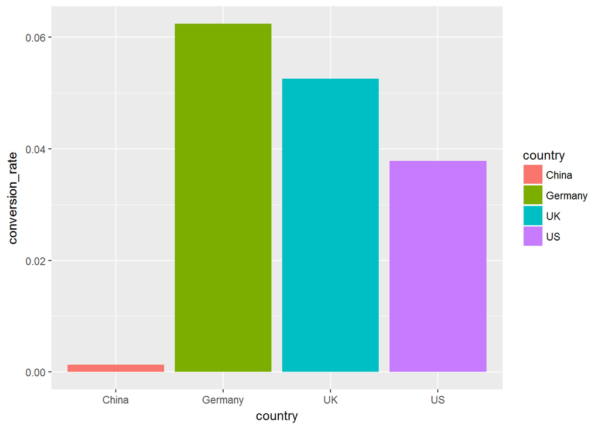

```r
data_country = data %>%
  group_by(country) %>%
  summarise(conversion_rate = mean(converted))
  ggplot(data=data_country, aes(x=country, y=conversion_rate)) + geom_bar(stat = "identity", aes(fill = country))
```

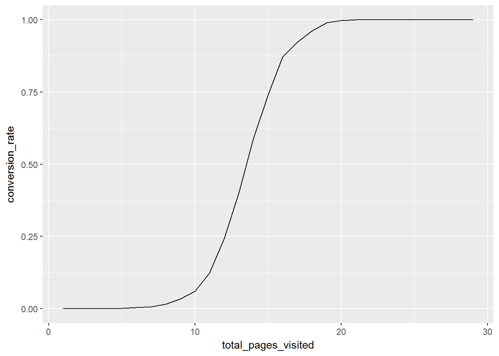

```r
# Here it clearly looks like Chinese convert at a much lower rate than other countries!

data_pages = data %>%
  group_by(total_pages_visited) %>%
  summarise(conversion_rate = mean(converted))
qplot(total_pages_visited, conversion_rate, data=data_pages, geom="line")
```

```r
# Definitely spending more time on the site implies higher probability of conversion
```